# Analyse et exploration d’un jeu de données sur la thrombose coronaire

Ce jeu de données se penche sur les maladies cardiaques et comprends plusieurs variables en rapport avec cette thématique. La database contenait initialement 76 variables, mais le jeu de données publié lui n’en contient au final que 14.  
Les variables sont, par ordre d’apparition:  
1. Age.  
2. Sexe.  
3. Type de douleur thoracique.  
4. Tension au repos.  
5. Cholesterol sanguin (en mg/dl).  
6. Glycémie à jeun (> 120 mg/dl).  
7. Résultat de l’ECG au repos.  
8. Fréquence cardiaque maximum.  
9. Angine induite à l’effort.  
10. Depression du ST induit par l’exercise relativement au repos.  
11. Pente du segment ST au pic de l’exercice.  
12. Nombre de vaisseaux majeurs coloriés par fluroscopie.  
13. Etat de la thalassémie.  
14. Diagnostic de thrombose coronaire. Il est positif lors d’un rétrécissement d’un vaisseau majeur supérieur à 50%.  
Nous allons donc nous intéresser aux caractéristiques des différents groupes de patients, et chercher à comprendre comment ces caractéristiques influent sur l’apparition des maladies cardiovasculaires.

# I) Chargement des données

#### A) Nettoyage des données

Nous renommons les variables et les rendons plus explicites afin de facilter l’interprétation de nos futurs résultats.

#### B) Aperçu du jeu de données

| age | sex | chest_pain | resting_bpm | chol | fbs | resting_ecg | max_bpm | ex_angina | st_depression | slope | colorised_vessels | thalassemia | angiographic_disease | age_class |
| --- | --- | --- | --- | --- | --- | --- | --- | --- | --- | --- | --- | --- | --- | --- |
| 63 | M | non-anginal pain | 145 | 233 | > 120 mg/dl | normal | 150 | FALSE | 2.3 | upsloping | 0 | normal | TRUE | [60,65) |
| 37 | M | atypical angina | 130 | 250 | <= 120 mg/dl | ST-T wave abnormality | 187 | FALSE | 3.5 | upsloping | 0 | fixed defect | TRUE | [35,40) |
| 41 | F | typical angina | 130 | 204 | <= 120 mg/dl | normal | 172 | FALSE | 1.4 | downsloping | 0 | fixed defect | TRUE | [40,45) |
| 56 | M | typical angina | 120 | 236 | <= 120 mg/dl | ST-T wave abnormality | 178 | FALSE | 0.8 | downsloping | 0 | fixed defect | TRUE | [55,60) |
| 57 | F | asymptomatic | 120 | 354 | <= 120 mg/dl | ST-T wave abnormality | 163 | TRUE | 0.6 | downsloping | 0 | fixed defect | TRUE | [55,60) |
| 57 | M | asymptomatic | 140 | 192 | <= 120 mg/dl | ST-T wave abnormality | 148 | FALSE | 0.4 | flat | 0 | normal | TRUE | [55,60) |

#### C) Résumé des données et leur réparttion

```
##       age        sex                chest_pain   resting_bpm
##  Min.   :29.00   F: 96   asymptomatic    :143   Min.   : 94.0
##  1st Qu.:47.50   M:207   typical angina  : 50   1st Qu.:120.0
##  Median :55.00           atypical angina : 87   Median :130.0
##  Mean   :54.37           non-anginal pain: 23   Mean   :131.6
##  3rd Qu.:61.00                                  3rd Qu.:140.0
##  Max.   :77.00                                  Max.   :200.0
##
##       chol                 fbs                            resting_ecg
##  Min.   :126.0   <= 120 mg/dl:258   normal                      :147
##  1st Qu.:211.0   > 120 mg/dl : 45   ST-T wave abnormality       :152
##  Median :240.0                      left ventricular hypertrophy:  4
##  Mean   :246.3
##  3rd Qu.:274.5
##  Max.   :564.0
##
##     max_bpm      ex_angina       st_depression          slope
##  Min.   : 71.0   Mode :logical   Min.   :0.00   upsloping  : 21
##  1st Qu.:133.5   FALSE:204       1st Qu.:0.00   flat       :140
##  Median :153.0   TRUE :99        Median :0.80   downsloping:142
##  Mean   :149.6                   Mean   :1.04
##  3rd Qu.:166.0                   3rd Qu.:1.60
##  Max.   :202.0                   Max.   :6.20
##
##  colorised_vessels            thalassemia  angiographic_disease
##  0:175             unknown          :  2   Mode :logical
##  1: 65             normal           : 18   FALSE:138
##  2: 38             fixed defect     :166   TRUE :165
##  3: 20             reversable defect:117
##  4:  5
##
##
##    age_class
##  [55,60):69
##  [50,55):56
##  [60,65):49
##  [40,45):40
##  [45,50):32
##  [65,70):31
##  (Other):26
```

# II) Exploration du jeu de données

#### A) Analyse de la population de l’étude

Le jeu de données comporte 303 patients, dont 207 hommes et 96 femmes.

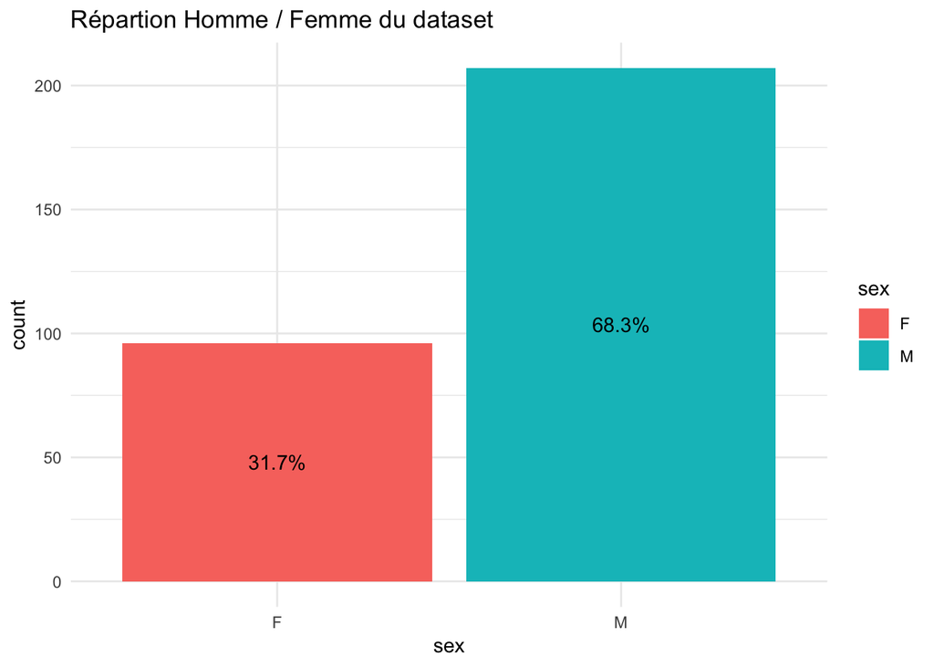

La répartition des patients par tranche d’âge est la suivante:

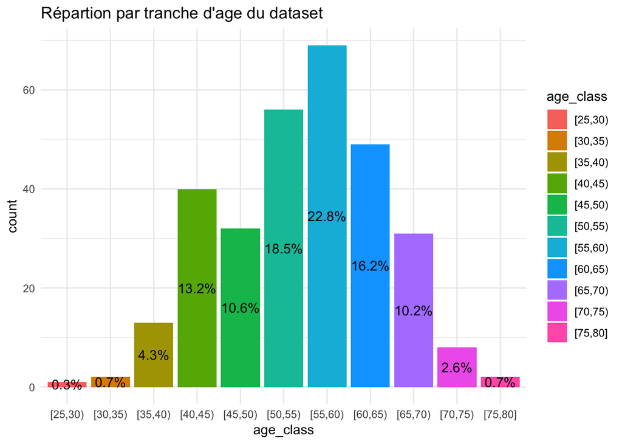

Nous remarquons donc qu’il y a 2 fois plus d’hommes que de femmes. Afin d’avoir des résultats interprétables il serait donc intéressant de travailler à partir de ratios ou de pourcentage pour chaque sexe. Enfin, plus de 90% des patients ont entre 40 et 70 ans. Il sera donc compliqué d’étendre nos résultats au delà de cette tranche d’âge.

#### B) Recherche de corrélations

##### 1) Corrélations générales

Nous essayons par cette estimation des corrélations entre variables d’avoir une première idée des facteurs qui semblent impacter la survenue, ou l’abscence, de thrombose coronaire. Il semble donc que les variables telles que la glycémie à jeun, le cholestérol, la fréquence cardiaque de repos ou encore les résultats de l’ecg de repos ne soient que très peu correlées avec la survenue de thrombose coronaire.  
À l’inverse, le nombre de vaisseaux colorés, les douleurs thoraciques, les angines induites à l’effort ou encore la dépression du ST semblent avoir une bonne valeur prédictive du diagnostic de thrombose coronaire.  
Par la suite, nous nous pencherons tour à tour sur chaque variables afin de voir dans quelle mesure elle possède, ou non, un interêt dans le diagnostic de thrombose coronaire.

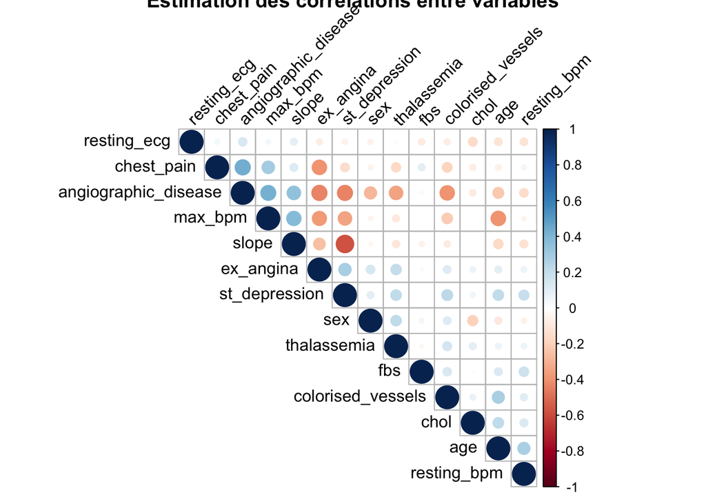

##### 2) Sexe

Ainsi on peut remarquer que dans ce jeu de données les femmes ont un risque de diagnostic de thrombose coronaire positif supérieur par rapport aux hommes.

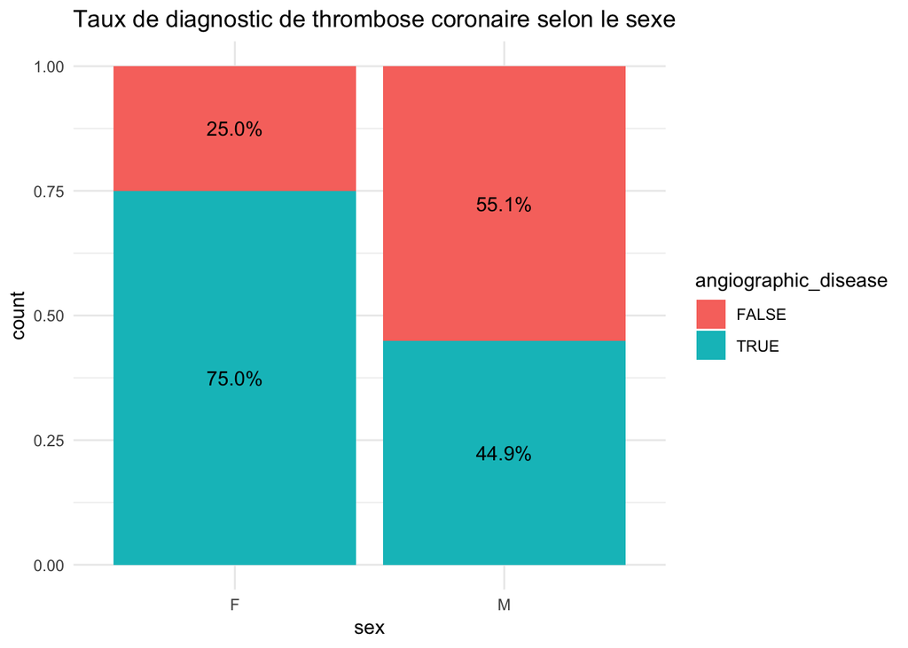

Rappel statistique:  
- La sensibilité d’un test est la probabilité que le test soit positif si la personne est atteinte de la maladie.  
- La spécificité d’un test est la probabilité que le test soit négatif si la personne testée est indemne de la maladie.  
- La valeur prédictive positive (VPP) d’un test est la probabilité que la personne soit réellement malade si son test est positif.  
- La valeur prédictive négative (VPN) d’un test est la probabilité que la personne n’ait pas la maladie si son test est négatif.  
Tableau de contingence et valeurs statistiques:

```
##    angiographic_disease
## sex TRUE FALSE
##   F   72    24
##   M   93   114
```

```
##           Outcome +    Outcome -      Total
## Test +           72           24         96
## Test -           93          114        207
## Total           165          138        303
##
## Point estimates and 95 % CIs:
## ---------------------------------------------------------
## Apparent prevalence                    0.32 (0.26, 0.37)
## True prevalence                        0.54 (0.49, 0.60)
## Sensitivity                            0.44 (0.36, 0.52)
## Specificity                            0.83 (0.75, 0.89)
## Positive predictive value              0.75 (0.65, 0.83)
## Negative predictive value              0.55 (0.48, 0.62)
## Positive likelihood ratio              2.51 (1.68, 3.75)
## Negative likelihood ratio              0.68 (0.58, 0.80)
## ---------------------------------------------------------
```

##### 3) Age

On remarque aussi que plus l’âge augmente, plus le taux de diagnostic de thrombose coronaire positif semble diminuer. Comme vu précédement, on ne prend pas en compte, dans cette remarque, les tranches [20-40] et [70-80] du fait de leur faible effectif.

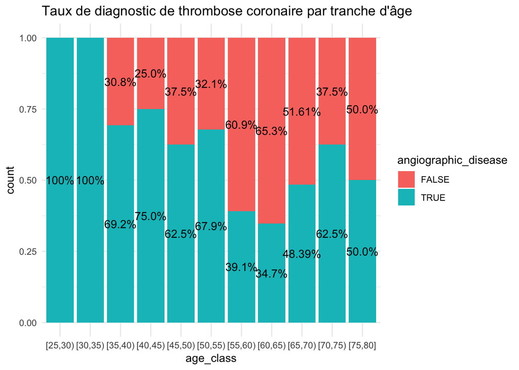

Tableau de contingence et valeurs statistiques:

```
##              angiographic_disease
## age_class_bis TRUE FALSE
##       [55,80]   65    94
##       [0,55)   100    44
```

```
##           Outcome +    Outcome -      Total
## Test +           65           94        159
## Test -          100           44        144
## Total           165          138        303
##
## Point estimates and 95 % CIs:
## ---------------------------------------------------------
## Apparent prevalence                    0.52 (0.47, 0.58)
## True prevalence                        0.54 (0.49, 0.60)
## Sensitivity                            0.39 (0.32, 0.47)
## Specificity                            0.32 (0.24, 0.40)
## Positive predictive value              0.41 (0.33, 0.49)
## Negative predictive value              0.31 (0.23, 0.39)
## Positive likelihood ratio              0.58 (0.46, 0.72)
## Negative likelihood ratio              1.90 (1.45, 2.50)
## ---------------------------------------------------------
```

##### 4) Fréquence cardiaque maximale

On peut ici remarquer qu’avoir une fréquence cardiaque maximale haute semble être un facteur de risque de thrombose coronaire.

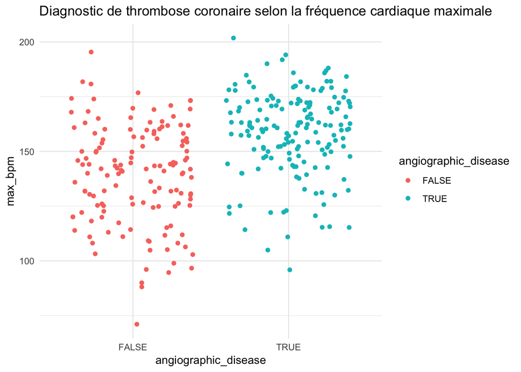

Tableau de contingence et valeurs statistiques:

```
##            angiographic_disease
## max_bpm_bis TRUE FALSE
##   [150,205]  122    49
##   [0,150)     43    89
```

```
##           Outcome +    Outcome -      Total
## Test +          122           49        171
## Test -           43           89        132
## Total           165          138        303
##
## Point estimates and 95 % CIs:
## ---------------------------------------------------------
## Apparent prevalence                    0.56 (0.51, 0.62)
## True prevalence                        0.54 (0.49, 0.60)
## Sensitivity                            0.74 (0.67, 0.80)
## Specificity                            0.64 (0.56, 0.72)
## Positive predictive value              0.71 (0.64, 0.78)
## Negative predictive value              0.67 (0.59, 0.75)
## Positive likelihood ratio              2.08 (1.63, 2.65)
## Negative likelihood ratio              0.40 (0.30, 0.54)
## ---------------------------------------------------------
```

##### 5) Fréquence cardiaque de repos

Cependant, la fréquence cardiaque de repos ne semble pas avoir une bonne valeur pronostique.

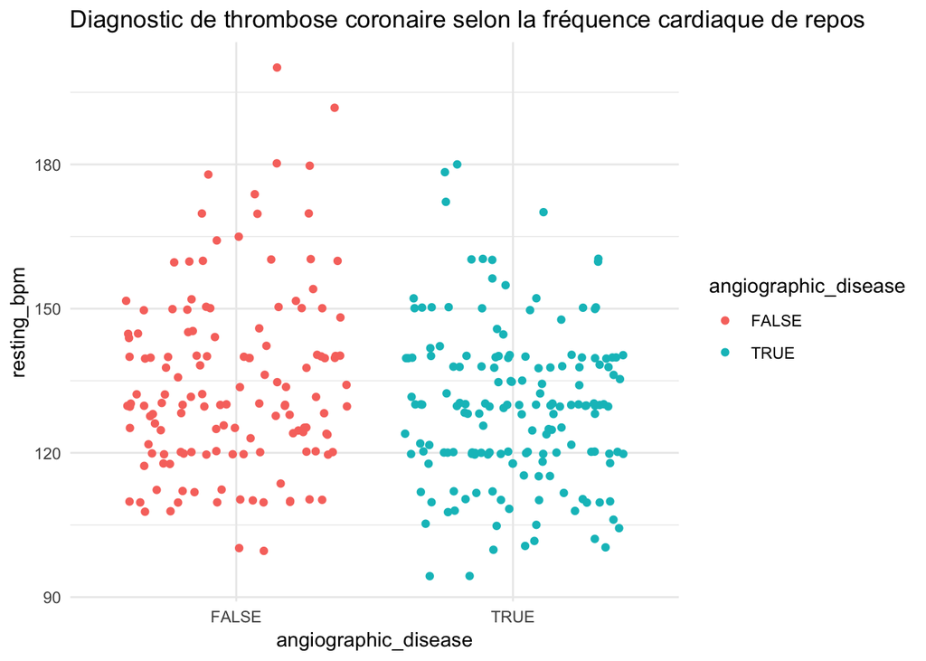

Tableau de contingence et valeurs statistiques:

```
##                angiographic_disease
## resting_bpm_bis TRUE FALSE
##       [120,205]  128   115
##       [0,120)     37    23
```

```
##           Outcome +    Outcome -      Total
## Test +          128          115        243
## Test -           37           23         60
## Total           165          138        303
##
## Point estimates and 95 % CIs:
## ---------------------------------------------------------
## Apparent prevalence                    0.80 (0.75, 0.85)
## True prevalence                        0.54 (0.49, 0.60)
## Sensitivity                            0.78 (0.70, 0.84)
## Specificity                            0.17 (0.11, 0.24)
## Positive predictive value              0.53 (0.46, 0.59)
## Negative predictive value              0.38 (0.26, 0.52)
## Positive likelihood ratio              0.93 (0.83, 1.04)
## Negative likelihood ratio              1.35 (0.84, 2.15)
## ---------------------------------------------------------
```

##### 6) Cholestérol

De même, le taux de cholestérol ne semble pas être corrélé au diagnostic de thrombose coronaire. Ce résultat paraît surprenant car le cholestérol est souvent cité comme facteur de risque dans les maladies cardiovasculaires.

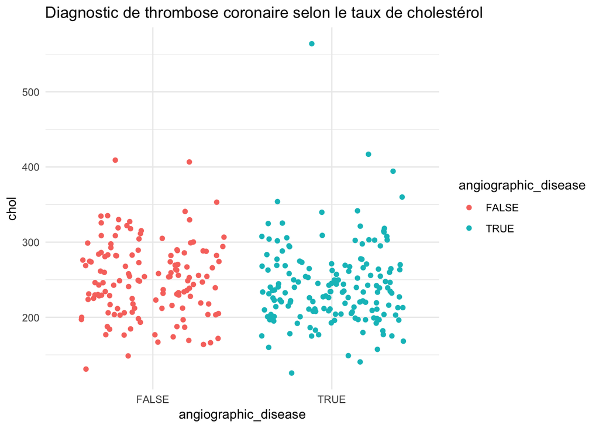

Tableau de contingence et valeurs statistiques:

```
##            angiographic_disease
## chol_bis    TRUE FALSE
##   [250,600]   61    68
##   [0,250)    104    70
```

```
##           Outcome +    Outcome -      Total
## Test +           61           68        129
## Test -          104           70        174
## Total           165          138        303
##
## Point estimates and 95 % CIs:
## ---------------------------------------------------------
## Apparent prevalence                    0.43 (0.37, 0.48)
## True prevalence                        0.54 (0.49, 0.60)
## Sensitivity                            0.37 (0.30, 0.45)
## Specificity                            0.51 (0.42, 0.59)
## Positive predictive value              0.47 (0.38, 0.56)
## Negative predictive value              0.40 (0.33, 0.48)
## Positive likelihood ratio              0.75 (0.58, 0.97)
## Negative likelihood ratio              1.24 (1.02, 1.52)
## ---------------------------------------------------------
```

##### 7) Douleur thoracique

Nous regroupons ici l’ensemble des douleurs thoraciques symptomatiques, cela comprend les angines typiques, atypiques et les douleurs non-angineuse. La présence de douleur thoracique, peu importe le type, semble hautement liée au diagnostic de thrombose coronaire.

```
##
## asymptomatic  symptomatic
##          143          160
```

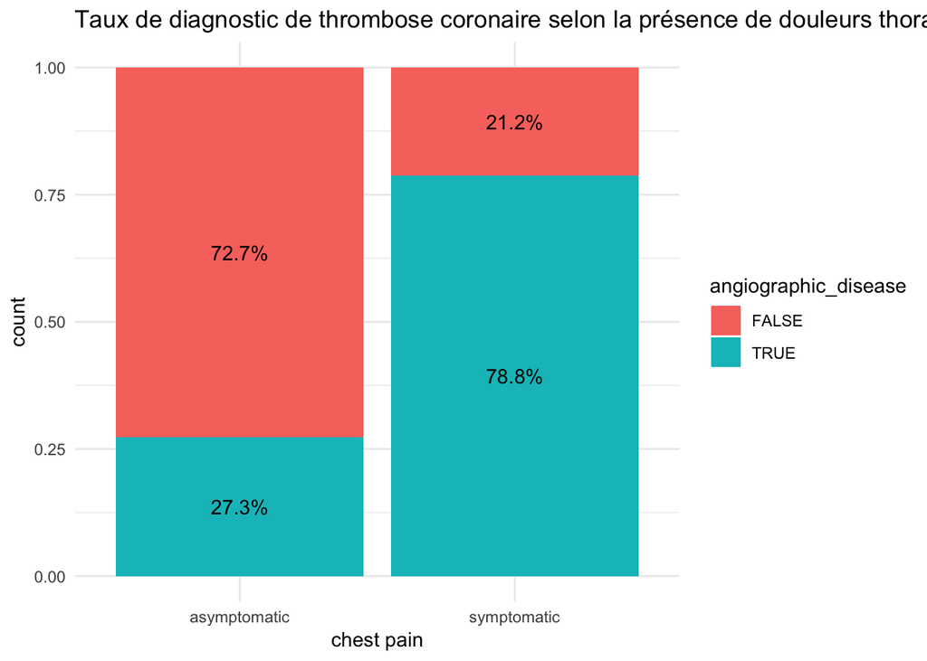

Tableau de contingence et valeurs statistiques:

```
##               angiographic_disease
## chest_pain.reg TRUE FALSE
##   symptomatic   126    34
##   asymptomatic   39   104
```

```
##           Outcome +    Outcome -      Total
## Test +          126           34        160
## Test -           39          104        143
## Total           165          138        303
##
## Point estimates and 95 % CIs:
## ---------------------------------------------------------
## Apparent prevalence                    0.53 (0.47, 0.59)
## True prevalence                        0.54 (0.49, 0.60)
## Sensitivity                            0.76 (0.69, 0.83)
## Specificity                            0.75 (0.67, 0.82)
## Positive predictive value              0.79 (0.72, 0.85)
## Negative predictive value              0.73 (0.65, 0.80)
## Positive likelihood ratio              3.10 (2.29, 4.20)
## Negative likelihood ratio              0.31 (0.23, 0.42)
## ---------------------------------------------------------
```

##### 8) Thalassémie

Ici aussi, il semble que le fait d’être atteint d’une thalassémie irreversible soit lié à la présence d’une maladie coronarienne.

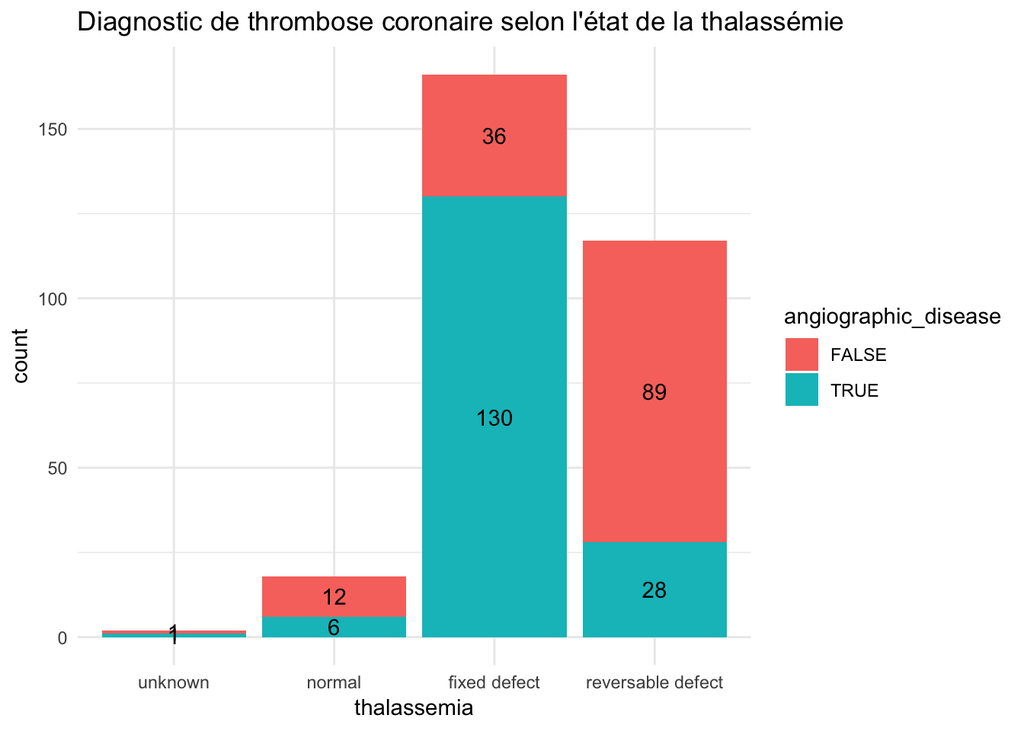

Tableau de contingence et valeurs statistiques:

```
##                   angiographic_disease
## thalassemia.reg    TRUE FALSE
##   fixed defect      130    36
##   non-fixed defect   35   102
```

```
##           Outcome +    Outcome -      Total
## Test +          130           36        166
## Test -           35          102        137
## Total           165          138        303
##
## Point estimates and 95 % CIs:
## ---------------------------------------------------------
## Apparent prevalence                    0.55 (0.49, 0.60)
## True prevalence                        0.54 (0.49, 0.60)
## Sensitivity                            0.79 (0.72, 0.85)
## Specificity                            0.74 (0.66, 0.81)
## Positive predictive value              0.78 (0.71, 0.84)
## Negative predictive value              0.74 (0.66, 0.82)
## Positive likelihood ratio              3.02 (2.26, 4.04)
## Negative likelihood ratio              0.29 (0.21, 0.39)
## ---------------------------------------------------------
```

##### 9) Vaisseaux colorés

On remarque ici logiquement que plus il y a de vaisseaux colorés par le produit de contraste, moins il y a de thrombose coronaire. En effet, mieux le coeur est perfusé, moins on risque de trouver de maladie cardiovasculaire. On note cependant que cette relation n’est pas vérifiée quand 4 vaisseaux prennent le contraste, mais il est possible d’imputer cette exception sur la faible taille de cette catégorie (n=5) qu’on ne considère alors plus comme significative. Une relation dose-effet est aussi observable.

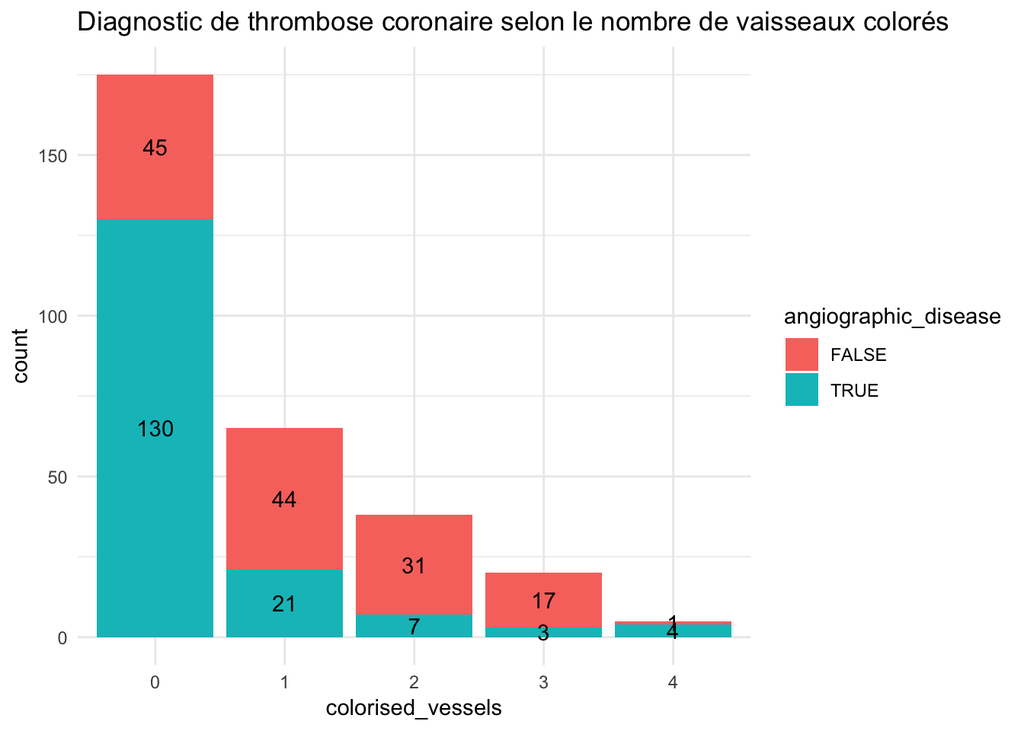

Tableau de contingence et valeurs statistiques:

```
##            angiographic_disease
## vessels.reg TRUE FALSE
##       [0-1]  151    89
##       [2-4]   14    49
```

```
##           Outcome +    Outcome -      Total
## Test +          151           89        240
## Test -           14           49         63
## Total           165          138        303
##
## Point estimates and 95 % CIs:
## ---------------------------------------------------------
## Apparent prevalence                    0.79 (0.74, 0.84)
## True prevalence                        0.54 (0.49, 0.60)
## Sensitivity                            0.92 (0.86, 0.95)
## Specificity                            0.36 (0.28, 0.44)
## Positive predictive value              0.63 (0.56, 0.69)
## Negative predictive value              0.78 (0.66, 0.87)
## Positive likelihood ratio              1.42 (1.24, 1.62)
## Negative likelihood ratio              0.24 (0.14, 0.41)
## ---------------------------------------------------------
```

##### 10) Glycémie à jeun

Comme vu dans le graphique de corrélation général, la glycémie à jeun ne semble pas du tout corrélée avec le diagnostic de thrombose coronaire.

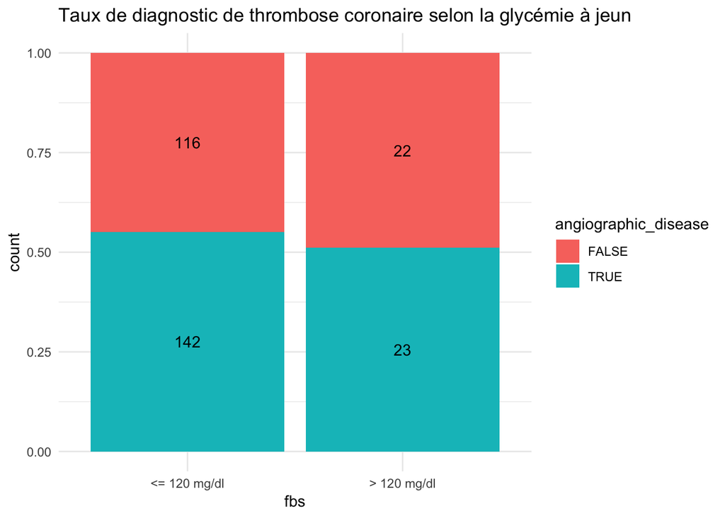

Tableau de contingence et valeurs statistiques:

```
##               angiographic_disease
## fbs            TRUE FALSE
##   <= 120 mg/dl  142   116
##   > 120 mg/dl    23    22
```

```
##           Outcome +    Outcome -      Total
## Test +          142          116        258
## Test -           23           22         45
## Total           165          138        303
##
## Point estimates and 95 % CIs:
## ---------------------------------------------------------
## Apparent prevalence                    0.85 (0.81, 0.89)
## True prevalence                        0.54 (0.49, 0.60)
## Sensitivity                            0.86 (0.80, 0.91)
## Specificity                            0.16 (0.10, 0.23)
## Positive predictive value              0.55 (0.49, 0.61)
## Negative predictive value              0.49 (0.34, 0.64)
## Positive likelihood ratio              1.02 (0.93, 1.13)
## Negative likelihood ratio              0.87 (0.51, 1.50)
## ---------------------------------------------------------
```

##### 11) ECG de repos

On observe qu’il y a moins de thrombose coronaire chez les patients avec un ECG normal, mais la différence ne semble pas très significative.

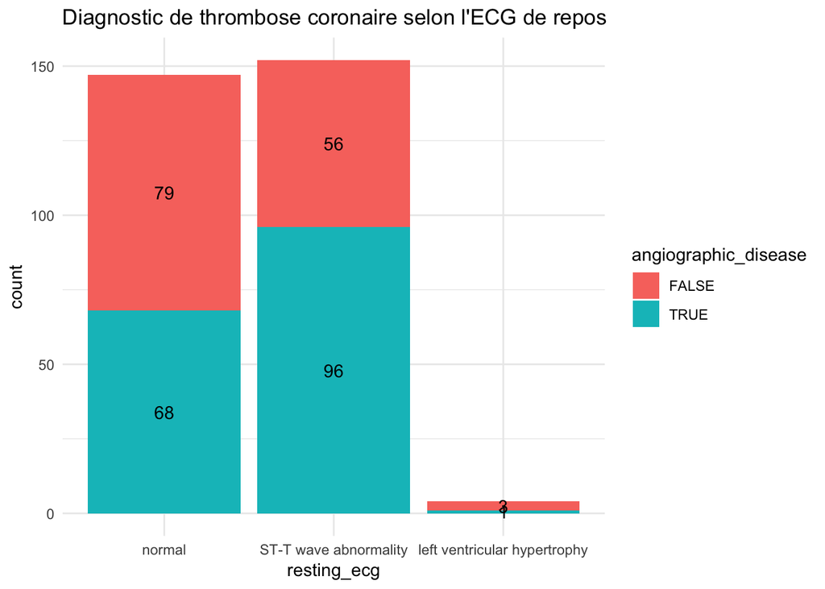

Tableau de contingence et valeurs statistiques:

```
##          angiographic_disease
## ecg.reg   TRUE FALSE
##   anormal   97    59
##   normal    68    79
```

```
##           Outcome +    Outcome -      Total
## Test +           97           59        156
## Test -           68           79        147
## Total           165          138        303
##
## Point estimates and 95 % CIs:
## ---------------------------------------------------------
## Apparent prevalence                    0.51 (0.46, 0.57)
## True prevalence                        0.54 (0.49, 0.60)
## Sensitivity                            0.59 (0.51, 0.66)
## Specificity                            0.57 (0.49, 0.66)
## Positive predictive value              0.62 (0.54, 0.70)
## Negative predictive value              0.54 (0.45, 0.62)
## Positive likelihood ratio              1.38 (1.09, 1.73)
## Negative likelihood ratio              0.72 (0.57, 0.91)
## ---------------------------------------------------------
```

##### 12) Angine induite à l’effort

Il semblerait que les patients atteints de thrombose coronaire aient moins de douleurs angineuses à l’effort. Ce résultat semble contre-intuitif, mais il pourrait permettre de faire un diagnostic différentiel avec d’autres maladies cardiovasculaires.

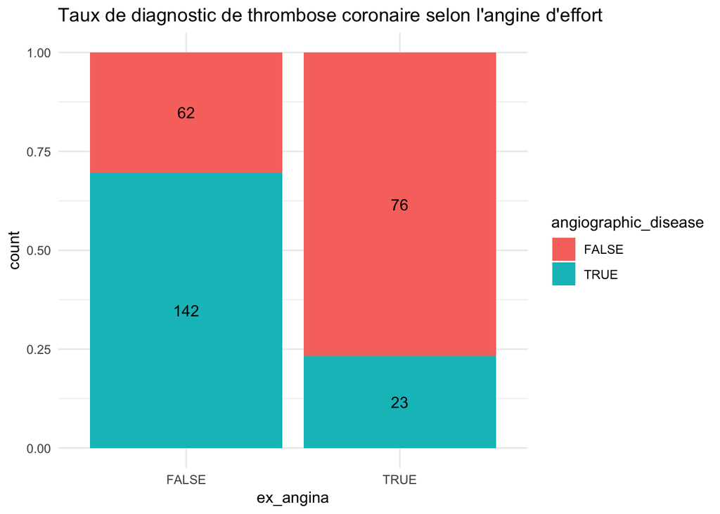

Tableau de contingence et valeurs statistiques:

```
##              angiographic_disease
## ex_angina.reg TRUE FALSE
##         FALSE  142    62
##         TRUE    23    76
```

```
##           Outcome +    Outcome -      Total
## Test +          142           62        204
## Test -           23           76         99
## Total           165          138        303
##
## Point estimates and 95 % CIs:
## ---------------------------------------------------------
## Apparent prevalence                    0.67 (0.62, 0.73)
## True prevalence                        0.54 (0.49, 0.60)
## Sensitivity                            0.86 (0.80, 0.91)
## Specificity                            0.55 (0.46, 0.64)
## Positive predictive value              0.70 (0.63, 0.76)
## Negative predictive value              0.77 (0.67, 0.85)
## Positive likelihood ratio              1.92 (1.58, 2.33)
## Negative likelihood ratio              0.25 (0.17, 0.38)
## ---------------------------------------------------------
```

##### 13) Dépression du segement ST induit à l’effort

On constate que très peu de patient atteint de thrombose coronaire ont une dépression du segment ST supérieure à 2 lors d’un effort.

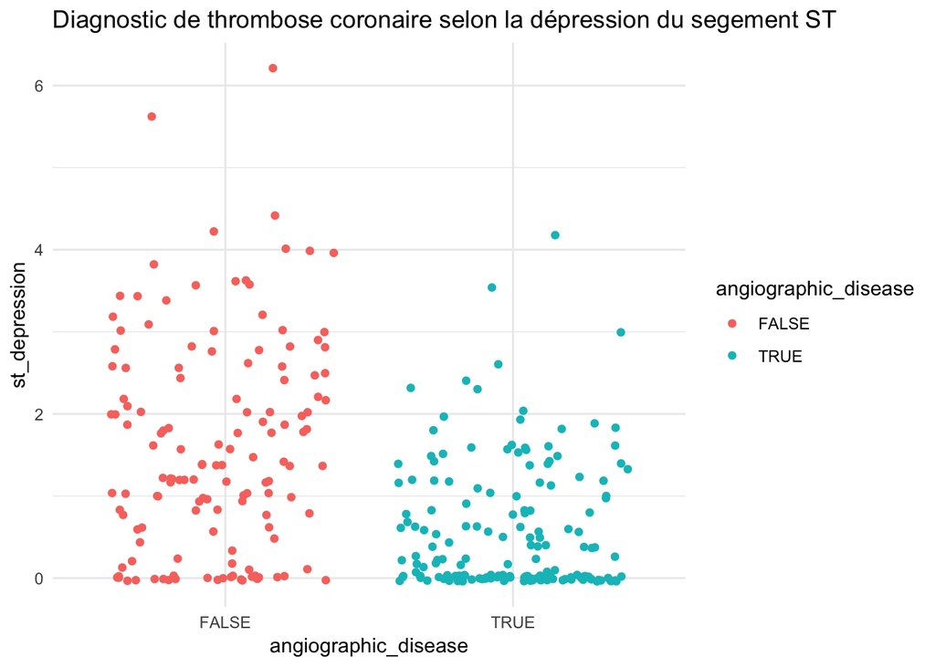

Tableau de contingence et valeurs statistiques:

```
##           angiographic_disease
## st_dep_bis TRUE FALSE
##    [0,2)    156    88
##    [2,6.5]    9    50
```

```
##           Outcome +    Outcome -      Total
## Test +          156           88        244
## Test -            9           50         59
## Total           165          138        303
##
## Point estimates and 95 % CIs:
## ---------------------------------------------------------
## Apparent prevalence                    0.81 (0.76, 0.85)
## True prevalence                        0.54 (0.49, 0.60)
## Sensitivity                            0.95 (0.90, 0.97)
## Specificity                            0.36 (0.28, 0.45)
## Positive predictive value              0.64 (0.58, 0.70)
## Negative predictive value              0.85 (0.73, 0.93)
## Positive likelihood ratio              1.48 (1.30, 1.69)
## Negative likelihood ratio              0.15 (0.08, 0.30)
## ---------------------------------------------------------
```

##### 14) Pente du segement ST lors de l’effort

Il semblerai qu’avoir une pente descendante du segment ST lors d’un effort soit associé avec une thrombose coronaire.

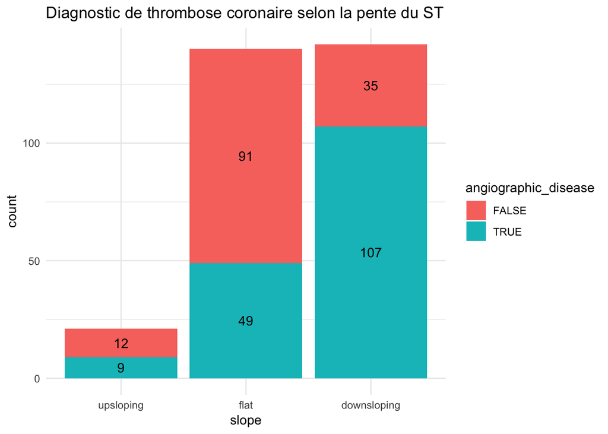

Tableau de contingence et valeurs statistiques:

```
##                    angiographic_disease
## slope.reg           TRUE FALSE
##   downsloping        107    35
##   flat or upsloping   58   103
```

```
##           Outcome +    Outcome -      Total
## Test +          107           35        142
## Test -           58          103        161
## Total           165          138        303
##
## Point estimates and 95 % CIs:
## ---------------------------------------------------------
## Apparent prevalence                    0.47 (0.41, 0.53)
## True prevalence                        0.54 (0.49, 0.60)
## Sensitivity                            0.65 (0.57, 0.72)
## Specificity                            0.75 (0.67, 0.82)
## Positive predictive value              0.75 (0.67, 0.82)
## Negative predictive value              0.64 (0.56, 0.71)
## Positive likelihood ratio              2.56 (1.88, 3.48)
## Negative likelihood ratio              0.47 (0.37, 0.59)
## ---------------------------------------------------------
```

#### B) Premiers pas vers un questionnaire/test diagnostic

On retire certaines variables qui n’ont à priori que très peu d’interêt selon nos observations précédentes, afin d’alléger la visualisation. Ainsi on retire le cholestérol, la glycémie à jeun et le fréquence cardiaque au repos.

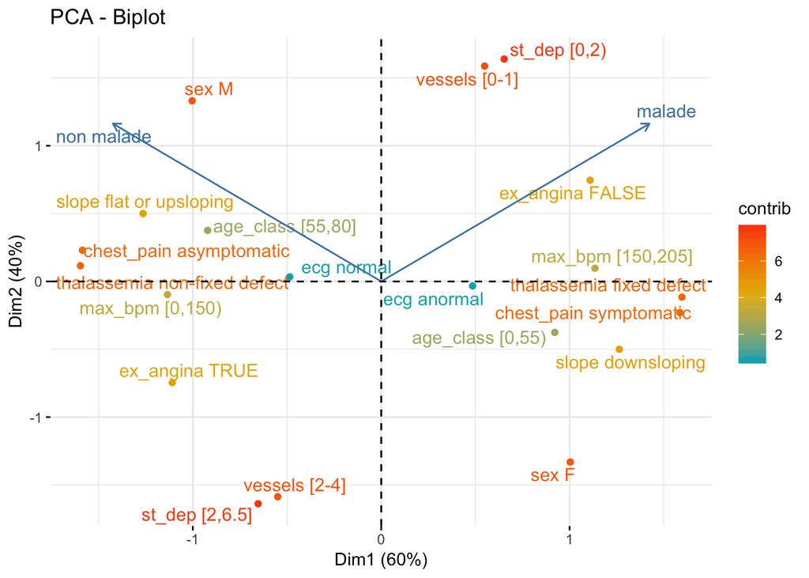

#### C) Applicable tout de suite à la clinique

##### 1) Les 3 variables les plus proches

On sélectionne les 3 variables les plus proches du point “malade”.  
Ainsi, on considère qu’il est à risque si sa dépression du segment ST est comprise entre 0 et 2, qu’il n’a pas de douleur angineuse à l’effort et que son nombre de vaisseaux prenant le contraste soit compris entre 0 et 1.  
Mais l’injection de produit de contraste est un geste invasif et ne sera probablement pas accépté en tant qu’examen de routine.

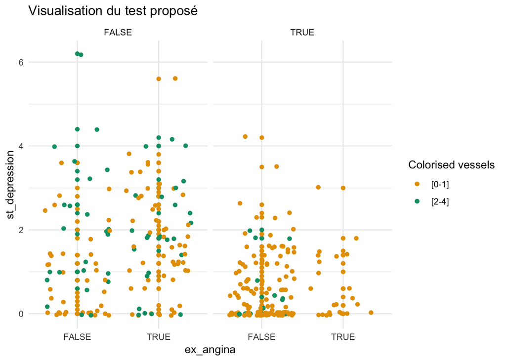

Tableau de contingence et valeurs statistiques:

```
##           Outcome +    Outcome -      Total
## Test +          122           32        154
## Test -           29           91        120
## Total           151          123        274
##
## Point estimates and 95 % CIs:
## ---------------------------------------------------------
## Apparent prevalence                    0.56 (0.50, 0.62)
## True prevalence                        0.55 (0.49, 0.61)
## Sensitivity                            0.81 (0.74, 0.87)
## Specificity                            0.74 (0.65, 0.81)
## Positive predictive value              0.79 (0.72, 0.85)
## Negative predictive value              0.76 (0.67, 0.83)
## Positive likelihood ratio              3.11 (2.28, 4.23)
## Negative likelihood ratio              0.26 (0.18, 0.37)
## ---------------------------------------------------------
```

##### 2) Test d’effort

Il semblerait donc qu’en demandant au patient de faire une épreuve d’effort on puisse tout de même avoir une bonne idée de la présence ou non de thrombose coronaire.  
On considère qu’il est à risque si sa dépression, à l’effort, du segment ST est comprise entre 0 et 2, qu’il n’a pas de douleur angineuse à l’effort mais qu’il a une douleur thoracique symptomatique au repos.

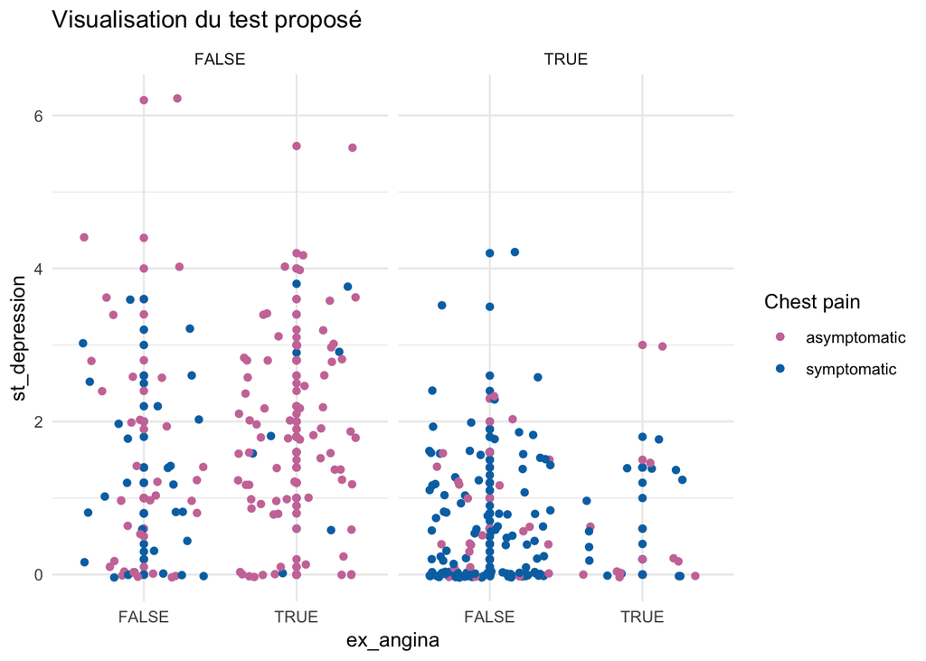

Tableau de contingence et valeurs statistiques:

```
##           Outcome +    Outcome -      Total
## Test +          108           22        130
## Test -           57          116        173
## Total           165          138        303
##
## Point estimates and 95 % CIs:
## ---------------------------------------------------------
## Apparent prevalence                    0.43 (0.37, 0.49)
## True prevalence                        0.54 (0.49, 0.60)
## Sensitivity                            0.65 (0.58, 0.73)
## Specificity                            0.84 (0.77, 0.90)
## Positive predictive value              0.83 (0.76, 0.89)
## Negative predictive value              0.67 (0.60, 0.74)
## Positive likelihood ratio              4.11 (2.76, 6.12)
## Negative likelihood ratio              0.41 (0.33, 0.51)
## ---------------------------------------------------------
```

##### 3) Test sensible

On peut enfin chercher à faire un test diagnostic plus sensible.  
On retient au final 5 critères:  
- thalassemie (average)  
- chest pain (average)  
- colorisses vessels (sensible)  
- ex_angina (sensible)  
- st_depression (sensible)  
Il serait possible d’utiliser ce test afin de sélectionner un maximum de patient, quitte à avoir certains “faux positifs”, qu’on éliminerait avec un dosage des troponines sanguines, excellent marqueur biologique du dommage myocardique.

```
##           Outcome +    Outcome -      Total
## Test +          155           57        212
## Test -           10           81         91
## Total           165          138        303
##
## Point estimates and 95 % CIs:
## ---------------------------------------------------------
## Apparent prevalence                    0.70 (0.64, 0.75)
## True prevalence                        0.54 (0.49, 0.60)
## Sensitivity                            0.94 (0.89, 0.97)
## Specificity                            0.59 (0.50, 0.67)
## Positive predictive value              0.73 (0.67, 0.79)
## Negative predictive value              0.89 (0.81, 0.95)
## Positive likelihood ratio              2.27 (1.86, 2.79)
## Negative likelihood ratio              0.10 (0.06, 0.19)
## ---------------------------------------------------------
```